# Donor Prospecting

## Library Includes

```r
library(tidyverse)      # General utility packages
library(caret)          # Used for up/down sampling imbalanced classes.
library(unbalanced)     # Class imbalance management via Synthetic Minority Oversampling TEchnique.
library(janitor)        # Used for everyday use, such as nice console-based distributions.
library(caTools)        # Used for train-test splitting
library(corrplot)       # Visual correlation plotting
library(car)            # Useful toolset specific to regression models
library(InformationValue) # Useful for finding precise cutoff values for probabilistic predictions.
```

## Preparing Data

```r
donors <- read_csv("data/donors.csv", col_types = "nnffnnnnnnnnffffffffff")
```

```r
options(width = 100)
glimpse(donors)
```

```
Rows: 95,412
Columns: 22
$ age                     <dbl> 60, 46, NA, 70, 78, NA, 38, NA, NA, 65, NA, 75, 72, NA, 70, NA, 4…
$ numberChildren          <dbl> NA, 1, NA, NA, 1, NA, 1, NA, NA, NA, NA, NA, 2, NA, NA, NA, NA, 1…
$ incomeRating            <fct> NA, 6, 3, 1, 3, NA, 4, 2, 3, NA, 2, 1, 4, NA, 4, 1, 1, 7, 4, NA, …
$ wealthRating            <fct> NA, 9, 1, 4, 2, NA, 6, 9, 2, NA, 0, 5, 2, NA, 6, 9, 5, NA, 4, NA,…
$ mailOrderPurchases      <dbl> 0, 16, 2, 2, 60, 0, 0, 1, 0, 0, 0, 3, 16, 0, 17, 0, 0, 0, 6, 0, 1…
$ totalGivingAmount       <dbl> 240, 47, 202, 109, 254, 51, 107, 31, 199, 28, 20, 25, 48, 245, 74…
$ numberGifts             <dbl> 31, 3, 27, 16, 37, 4, 14, 5, 11, 3, 1, 2, 9, 12, 7, 2, 3, 4, 10, …
$ smallestGiftAmount      <dbl> 5, 10, 2, 2, 3, 10, 3, 5, 10, 3, 20, 10, 4, 5, 5, 10, 10, 15, 5, …
$ largestGiftAmount       <dbl> 12, 25, 16, 11, 15, 16, 12, 11, 22, 15, 20, 15, 7, 50, 15, 15, 15…
$ averageGiftAmount       <dbl> 7.741935, 15.666667, 7.481481, 6.812500, 6.864865, 12.750000, 7.6…
$ yearsSinceFirstDonation <dbl> 8, 3, 7, 10, 11, 3, 10, 3, 9, 3, 1, 1, 8, 5, 4, 3, 3, 9, 11, 2, 1…
$ monthsSinceLastDonation <dbl> 14, 14, 14, 14, 13, 20, 22, 18, 19, 22, 12, 14, 13, 2, 20, 14, 14…
$ inHouseDonor            <fct> FALSE, FALSE, FALSE, FALSE, TRUE, FALSE, FALSE, FALSE, FALSE, FAL…
$ plannedGivingDonor      <fct> FALSE, FALSE, FALSE, FALSE, FALSE, FALSE, FALSE, FALSE, FALSE, FA…
$ sweepstakesDonor        <fct> FALSE, FALSE, FALSE, FALSE, FALSE, FALSE, FALSE, FALSE, FALSE, FA…
$ P3Donor                 <fct> FALSE, FALSE, FALSE, FALSE, TRUE, FALSE, FALSE, FALSE, FALSE, FAL…
$ state                   <fct> IL, CA, NC, CA, FL, AL, IN, LA, IA, TN, KS, IN, MN, LA, UT, CA, M…
$ urbanicity              <fct> town, suburb, rural, rural, suburb, town, town, town, rural, town…
$ socioEconomicStatus     <fct> average, highest, average, average, average, average, average, av…
$ isHomeowner             <fct> NA, TRUE, NA, NA, TRUE, NA, TRUE, NA, NA, NA, NA, NA, TRUE, NA, T…
$ gender                  <fct> female, male, male, female, female, NA, female, female, male, mal…
$ respondedMailing        <fct> FALSE, FALSE, FALSE, FALSE, FALSE, FALSE, FALSE, FALSE, FALSE, FA…
```

Examining categorical features first.

```r
options(width = 100)
donors %>%
  select(where(is.factor)) %>%
  summary()
```

```
  incomeRating    wealthRating   inHouseDonor  plannedGivingDonor sweepstakesDonor  P3Donor
 5      :15451   9      : 7585   FALSE:88709   FALSE:95298        FALSE:93795      FALSE:93395
 2      :13114   8      : 6793   TRUE : 6703   TRUE :  114        TRUE : 1617      TRUE : 2017
 4      :12732   7      : 6198
 1      : 9022   6      : 5825
 3      : 8558   5      : 5280
 (Other):15249   (Other):18999
 NA's   :21286   NA's   :44732
     state        urbanicity    socioEconomicStatus isHomeowner     gender      respondedMailing
 CA     :17343   town  :19527   average:48638       TRUE:52354   female:51277   FALSE:90569
 FL     : 8376   suburb:21924   highest:28498       NA's:43058   male  :39094   TRUE : 4843
 TX     : 7535   rural :19790   lowest :15960                    joint :  365
 IL     : 6420   urban :12166   NA's   : 2316                    NA's  : 4676
 MI     : 5654   city  :19689
 NC     : 4160   NA's  : 2316
 (Other):45924
```

We see there are lots of NA’s to clean up / handle. We’ll start with incomeRating, for which we see below that 22.31% of the data is missing. Since logistic regression can’t handle any NA’s, we need to choose whether to delete or otherwise handle these types of situations. Since there’s so much missing data for this feature, we can’t delete the associated observations and will instead create a new factor value UNK for unknown.

```r
donors %>%
  select(incomeRating) %>%
  table(exclude = NULL) %>%
  prop.table()
```

```
.
         6          3          1          4          2          7          5       <NA>
0.08152014 0.08969522 0.09455834 0.13344233 0.13744602 0.07830252 0.16193980 0.22309563
```

```r
donors <- donors %>%
  mutate(incomeRating = as.character(incomeRating)) %>%
  mutate(incomeRating = as.factor(ifelse(is.na(incomeRating), "UNK", incomeRating)))
```

```r
donors %>%
  select(incomeRating) %>%
  table(exclude = NULL) %>%
  prop.table()
```

```
.
         1          2          3          4          5          6          7        UNK
0.09455834 0.13744602 0.08969522 0.13344233 0.16193980 0.08152014 0.07830252 0.22309563
```

Let’s use the same approach for other factor features with missing data.

```r
options(width = 100)
donors <- donors %>%
  mutate(wealthRating = as.character(wealthRating)) %>%
  mutate(wealthRating = as.factor(ifelse(
    is.na(wealthRating),
    "UNK",
    wealthRating))) %>%
  mutate(urbanicity = as.character(urbanicity)) %>%
  mutate(urbanicity = as.factor(ifelse(
    is.na(urbanicity),
    "UNK",
    urbanicity))) %>%
  mutate(socioEconomicStatus = as.character(socioEconomicStatus)) %>%
  mutate(socioEconomicStatus = as.factor(ifelse(
    is.na(socioEconomicStatus),
    "UNK",
    socioEconomicStatus))) %>%
  mutate(isHomeowner = as.character(isHomeowner)) %>%
  mutate(isHomeowner = as.factor(ifelse(
    is.na(isHomeowner),
    "UNK",
    isHomeowner))) %>%
  mutate(gender = as.character(gender)) %>%
  mutate(gender = as.factor(ifelse(
    is.na(gender),
    "UNK",
    gender)))

donors %>%
  select(where(is.factor)) %>%
  summary()
```

```
  incomeRating    wealthRating   inHouseDonor  plannedGivingDonor sweepstakesDonor  P3Donor
 UNK    :21286   UNK    :44732   FALSE:88709   FALSE:95298        FALSE:93795      FALSE:93395
 5      :15451   9      : 7585   TRUE : 6703   TRUE :  114        TRUE : 1617      TRUE : 2017
 2      :13114   8      : 6793
 4      :12732   7      : 6198
 1      : 9022   6      : 5825
 3      : 8558   5      : 5280
 (Other):15249   (Other):18999
     state        urbanicity    socioEconomicStatus isHomeowner     gender      respondedMailing
 CA     :17343   city  :19689   average:48638       TRUE:52354   female:51277   FALSE:90569
 FL     : 8376   rural :19790   highest:28498       UNK :43058   joint :  365   TRUE : 4843
 TX     : 7535   suburb:21924   lowest :15960                    male  :39094
 IL     : 6420   town  :19527   UNK    : 2316                    UNK   : 4676
 MI     : 5654   UNK   : 2316
 NC     : 4160   urban :12166
 (Other):45924
```

Examining continuous numeric features next.

```r
options(width = 100)
donors %>%
  select(where(is.numeric)) %>%
  summary()
```

```
      age        numberChildren  mailOrderPurchases totalGivingAmount  numberGifts
 Min.   : 1.00   Min.   :1.00    Min.   :  0.000    Min.   :  13.0    Min.   :  1.000
 1st Qu.:48.00   1st Qu.:1.00    1st Qu.:  0.000    1st Qu.:  40.0    1st Qu.:  3.000
 Median :62.00   Median :1.00    Median :  0.000    Median :  78.0    Median :  7.000
 Mean   :61.61   Mean   :1.53    Mean   :  3.321    Mean   : 104.5    Mean   :  9.602
 3rd Qu.:75.00   3rd Qu.:2.00    3rd Qu.:  3.000    3rd Qu.: 131.0    3rd Qu.: 13.000
 Max.   :98.00   Max.   :7.00    Max.   :241.000    Max.   :9485.0    Max.   :237.000
 NA's   :23665   NA's   :83026
 smallestGiftAmount largestGiftAmount averageGiftAmount  yearsSinceFirstDonation
 Min.   :   0.000   Min.   :   5      Min.   :   1.286   Min.   : 0.000
 1st Qu.:   3.000   1st Qu.:  14      1st Qu.:   8.385   1st Qu.: 2.000
 Median :   5.000   Median :  17      Median :  11.636   Median : 5.000
 Mean   :   7.934   Mean   :  20      Mean   :  13.348   Mean   : 5.596
 3rd Qu.:  10.000   3rd Qu.:  23      3rd Qu.:  15.478   3rd Qu.: 9.000
 Max.   :1000.000   Max.   :5000      Max.   :1000.000   Max.   :13.000

 monthsSinceLastDonation
 Min.   : 0.00
 1st Qu.:12.00
 Median :14.00
 Mean   :14.36
 3rd Qu.:17.00
 Max.   :23.00
```

We see that both age and numberChildren have significant amounts of missing data. Let’s handle age first. In this instance, we will impute age based on the average age value of the given gender. This should prove more accurate than simply taking the age across the entire dataset.

```r
donors <- donors %>%
  group_by(gender) %>%
  mutate(age = ifelse(is.na(age), mean(age, na.rm = TRUE), age)) %>%
  ungroup()

donors %>%
  select(age) %>%
  summary()
```

```
      age
 Min.   : 1.00
 1st Qu.:52.00
 Median :61.95
 Mean   :61.67
 3rd Qu.:71.00
 Max.   :98.00
```

As can be seen above, age is now imputed, and the before and after summary statistics for the feature remained pretty similar. The second numeric feature to cleanup is numberChildren. In this case, grouping by gender doesn’t make any sense, and taking a mean wouldn’t either as we’d end up with fractional children. Here we will simply go for median imputation.

```r
donors <- donors %>%
  mutate(numberChildren = ifelse(
    is.na(numberChildren),
    median(numberChildren, na.rm = TRUE),
    numberChildren))

donors %>%
  select(numberChildren) %>%
  summary()
```

```
 numberChildren
 Min.   :1.000
 1st Qu.:1.000
 Median :1.000
 Mean   :1.069
 3rd Qu.:1.000
 Max.   :7.000
```

Now that missingness is dealt with, let’s look for outliers in our continuous numeric features.

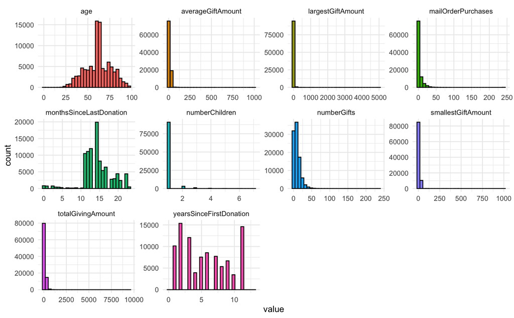

```r
donors %>%
  select(where(is.numeric)) %>%
  pivot_longer(cols = everything()) %>%
  ggplot(aes(x=value,fill=name)) +
    geom_histogram(color = "black", bins = 30, show.legend = FALSE) +
    facet_wrap(~ name, scales = "free", ncol = 4) +
    theme_minimal()
```

If we look above at the distributions, there’s two things I’m looking for - the shape of the distribution to be skewed, and the scale of the x-axis to span orders of magnitude with little if any data indexing under said bins. The following features meet this criteria: averageGiftAmount, largestGiftAmount, mailOrderPurchases, numberGifts, smallestGiftAmount, totalGivingAmount.

While sometimes outlier data might be deemed important with meaning to be gleaned, in this instance, we are going to simply remove them. The rule of thumb we’ll be using is that anything not in the range of (Q1 - 1.5 IQR) and (Q3 + 1.5 IQR) is an outlier, and can be removed.

```r
options(width = 100)
donors <- donors %>%
  filter(averageGiftAmount >= (quantile(averageGiftAmount, .25) - (1.5 * IQR(averageGiftAmount)))) %>%
  filter(averageGiftAmount <= (quantile(averageGiftAmount, .75) + (1.5 * IQR(averageGiftAmount)))) %>%
  filter(largestGiftAmount >= (quantile(largestGiftAmount, .25) - (1.5 * IQR(largestGiftAmount)))) %>%
  filter(largestGiftAmount <= (quantile(largestGiftAmount, .75) + (1.5 * IQR(largestGiftAmount)))) %>%
  filter(mailOrderPurchases >= (quantile(mailOrderPurchases, .25) - (1.5 * IQR(mailOrderPurchases)))) %>%
  filter(mailOrderPurchases <= (quantile(mailOrderPurchases, .75) + (1.5 * IQR(mailOrderPurchases)))) %>%
  filter(smallestGiftAmount >= (quantile(smallestGiftAmount, .25) - (1.5 * IQR(smallestGiftAmount)))) %>%
  filter(smallestGiftAmount <= (quantile(smallestGiftAmount, .75) + (1.5 * IQR(smallestGiftAmount)))) %>%
  filter(totalGivingAmount >= (quantile(totalGivingAmount, .25) - (1.5 * IQR(totalGivingAmount)))) %>%
  filter(totalGivingAmount <= (quantile(totalGivingAmount, .75) + (1.5 * IQR(totalGivingAmount))))

donors %>%
  select(where(is.numeric)) %>%
  select(averageGiftAmount,
         largestGiftAmount,
         mailOrderPurchases,
         numberGifts,
         smallestGiftAmount,
         totalGivingAmount) %>%
  summary()
```

```
 averageGiftAmount largestGiftAmount mailOrderPurchases  numberGifts     smallestGiftAmount
 Min.   : 1.364    Min.   : 5.00     Min.   :0.0000     Min.   : 1.000   Min.   : 0.000
 1st Qu.: 8.000    1st Qu.:12.00     1st Qu.:0.0000     1st Qu.: 3.000   1st Qu.: 3.000
 Median :10.800    Median :15.00     Median :0.0000     Median : 7.000   Median : 5.000
 Mean   :11.415    Mean   :16.63     Mean   :0.9507     Mean   : 8.876   Mean   : 6.833
 3rd Qu.:15.000    3rd Qu.:20.00     3rd Qu.:1.0000     3rd Qu.:13.000   3rd Qu.:10.000
 Max.   :26.000    Max.   :30.43     Max.   :7.0000     Max.   :71.000   Max.   :20.000
 totalGivingAmount
 Min.   : 14.00
 1st Qu.: 38.00
 Median : 70.00
 Mean   : 82.02
 3rd Qu.:114.78
 Max.   :245.00
```

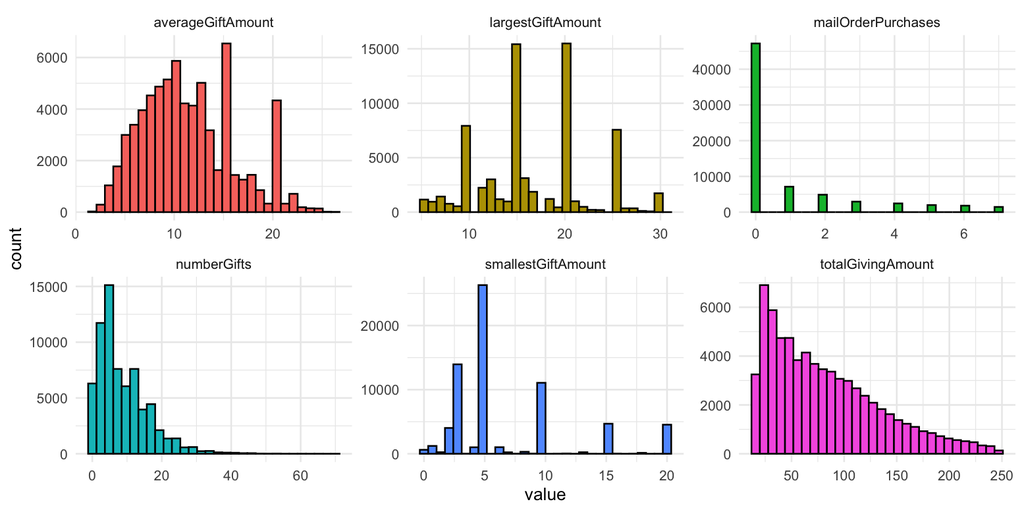

```r
donors %>%
  select(where(is.numeric)) %>%
  select(averageGiftAmount,
         largestGiftAmount,
         mailOrderPurchases,
         numberGifts,
         smallestGiftAmount,
         totalGivingAmount) %>%
  pivot_longer(cols = everything()) %>%
  ggplot(aes(x=value,fill=name)) +
    geom_histogram(color = "black", bins = 30, show.legend = FALSE) +
    facet_wrap(~ name, scales = "free", ncol = 3) +
    theme_minimal()
```

Out of curiosity, let’s see what the average age of respondents is by state.

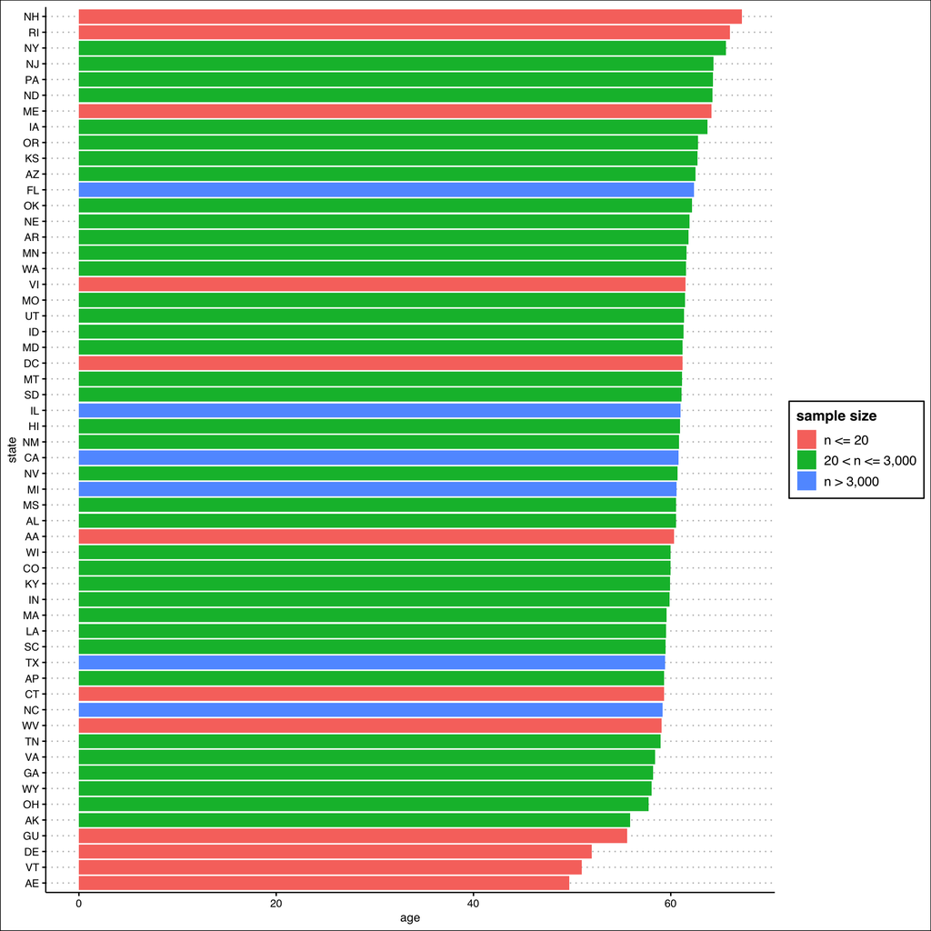

```r
ggplot(donors %>% group_by(state) %>% summarise(age = mean(age), n = n()),
       aes(reorder(state, age, FUN = sum),
           age,
           fill = cut(n,
                      breaks = c(-Inf, 20, 3000, Inf),
                      labels = c("n <= 20", "20 < n <= 3,000", "n > 3,000")))) +
  geom_col() +
  coord_flip() +
  theme_clean() +
  labs(fill = "sample size", x = "state")
```

As can be seen above, average age of respondents by state does seem to vary. What’s also worth noting is that state respondent participation is quite varied, with 12 states having less than or equal to 20 respondents. This may prove troubling when splitting our data in train/test as ‘state’ is a predictor for our target response, however the odds of capturing examples for each state in our train data is not high, in which case our model won’t be able to make predictions for unrecognized state predictors that show up in test data.

Let’s make our response variable simply 1 and 0 instead of TRUE and FALSE.

```r
donors <- donors %>%
  mutate(respondedMailing = as.factor(ifelse(respondedMailing==TRUE, 1, 0)))
```

## Splitting Data

```r
set.seed(420)
sampleSet <- sample.split(donors$respondedMailing, SplitRatio = 0.75)
donorsTrain <- subset(donors, sampleSet == TRUE)
donorsTest <- subset(donors, sampleSet == FALSE)
```

We’ll do a quick gut check to ensure our train and test sets look to have sampled in a truly random fashion by checking the proportion of TRUE(1)/FALSE(0) values for our desired response variable ‘respondedMailing’.

```r
donorsTrain %>%
  tabyl(respondedMailing) %>%
  arrange(desc(n))
```

```
 respondedMailing     n   percent
                0 49695 0.9489755
                1  2672 0.0510245
```

```r
donorsTest %>%
  tabyl(respondedMailing) %>%
  arrange(desc(n))
```

```
 respondedMailing     n    percent
                0 16565 0.94895738
                1   891 0.05104262
```

With the above clearly showing an equitable split has occurred, we now turn our heads toward the class imbalance issue for our response variable. Currently there’s roughly 95% to 5% class imbalance, so our model will be way better at predicting FALSE (0) than TRUE (1). Let’s balance this out for the training phase.

## Class Imbalance Management

Two approaches that could be taken for addressing our response class imbalance is over-sampling of the minority class, or under-sampling of the majority class. Both of these approaches can be accomplished using caret in the following way but this leaves us with a very small amount of train data given the extreme imbalance if we down sample, and a very large amount of duplicate train data if we up sample.

```r
set.seed(420)
downSample(donorsTrain, donorsTrain$respondedMailing) %>%
  select(-Class) %>%
  tabyl(respondedMailing) %>%
  arrange(desc(n))
```

```
 respondedMailing    n percent
                0 2672     0.5
                1 2672     0.5
```

As can be seen above, we’ve just dropped about 47K worth of training observations. Another option we can examine is the synthesis of new minority class instances. This can be accomplished using Synthetic Minority Oversampling TEchnique (SMOTE).

```r
set.seed(420)
smoted <- ubSMOTE(select(donorsTrain, -respondedMailing),
                  donorsTrain$respondedMailing,
                  perc.over = 100,
                  perc.under = 200)

donorsTrain <- smoted$X
donorsTrain$respondedMailing <- smoted$Y

donorsTrain %>%
  tabyl(respondedMailing) %>%
  arrange(desc(n))
```

```
 respondedMailing    n percent
                0 5344     0.5
                1 5344     0.5
```

## Model Preparation

A popular approach for building binomial logistic regression models is to use the generalized linear model (GLM) glm() function.

```r
donorsModel <- glm(data = donorsTrain, family = binomial, formula = respondedMailing ~ .)
```

## Model Evaluation

```r
donorsModel %>%
  summary()
```

```
Call:
glm(formula = respondedMailing ~ ., family = binomial, data = donorsTrain)

Deviance Residuals:
     Min        1Q    Median        3Q       Max
-2.91332  -1.01602   0.00018   1.11155   2.47947

Coefficients:
                             Estimate Std. Error z value             Pr(>|z|)
(Intercept)                  1.050823   0.261318   4.021 0.000057892931525337 ***
age                         -0.001025   0.001662  -0.617             0.537156
numberChildren              -0.155268   0.070106  -2.215             0.026776 *
incomeRating2                0.167110   0.092672   1.803             0.071352 .
incomeRating3                0.296278   0.101116   2.930             0.003389 **
incomeRating4                0.287097   0.097304   2.951             0.003172 **
incomeRating5                0.316106   0.095203   3.320             0.000899 ***
incomeRating6                0.266598   0.110468   2.413             0.015807 *
incomeRating7                0.322881   0.114338   2.824             0.004744 **
incomeRatingUNK              0.309430   0.090951   3.402             0.000669 ***
wealthRating1                0.036767   0.171224   0.215             0.829976
wealthRating2               -0.187836   0.174060  -1.079             0.280523
wealthRating3               -0.034950   0.166747  -0.210             0.833983
wealthRating4               -0.159143   0.165689  -0.960             0.336807
wealthRating5               -0.160746   0.163914  -0.981             0.326754
wealthRating6               -0.311323   0.161154  -1.932             0.053379 .
wealthRating7               -0.096344   0.160574  -0.600             0.548509
wealthRating8               -0.203904   0.161006  -1.266             0.205357
wealthRating9               -0.062472   0.162164  -0.385             0.700061
wealthRatingUNK             -0.444013   0.140314  -3.164             0.001554 **
mailOrderPurchases          -0.048500   0.014945  -3.245             0.001173 **
totalGivingAmount            0.002507   0.000963   2.604             0.009222 **
numberGifts                  0.005803   0.007589   0.765             0.444504
smallestGiftAmount           0.007284   0.010936   0.666             0.505369
largestGiftAmount           -0.034614   0.008271  -4.185 0.000028492058087605 ***
averageGiftAmount           -0.030639   0.017729  -1.728             0.083956 .
yearsSinceFirstDonation     -0.020891   0.011005  -1.898             0.057662 .
monthsSinceLastDonation     -0.038868   0.006049  -6.426 0.000000000131258605 ***
inHouseDonorTRUE             1.230233   0.076156  16.154 < 0.0000000000000002 ***
plannedGivingDonorTRUE       2.979191   1.041441   2.861             0.004228 **
sweepstakesDonorTRUE         1.073190   0.132436   8.103 0.000000000000000534 ***
```

[output cut: 56 more lines]

```
socioEconomicStatusUNK       0.546142   0.147708   3.697             0.000218 ***
isHomeownerUNK               0.012891   0.050481   0.255             0.798436
genderjoint                  0.857852   0.338218   2.536             0.011200 *
gendermale                   0.075864   0.044028   1.723             0.084873 .
genderUNK                    0.267793   0.093569   2.862             0.004210 **
---
Signif. codes:  0 ‘***’ 0.001 ‘**’ 0.01 ‘*’ 0.05 ‘.’ 0.1 ‘ ’ 1

(Dispersion parameter for binomial family taken to be 1)

    Null deviance: 14817  on 10687  degrees of freedom
Residual deviance: 13072  on 10596  degrees of freedom
AIC: 13256

Number of Fisher Scoring iterations: 12
```

```r
donorsPred1 <- predict(donorsModel, donorsTest, type = "response")
```

```
Error in model.frame.default(Terms, newdata, na.action = na.action, xlev = object$xlevels) :
  factor state has new levels ME, VT, GU, NH, VI
```

The above situation is a reflection of our train/test split, paired with uncommon factor values for the ‘state’ predictor. That is, our test set has values for the ‘state’ predictor that weren’t provided in the train dataset so the model doesn’t know what to do with them.

For the sake of simplicity, we’ll simply remove the nominal amount of records from donorsTest blocking our progress. In a production environment, you wouldn’t want to do this as you should train your model to account for all possible inputs.

```r
donorsTest <- donorsTest %>%
  filter(!state %in% c("ME", "VT", "GU", "NH", "VI"))
```

```r
donorsPred1 <- predict(donorsModel, donorsTest, type = "response")
head(donorsPred1)
```

```
        1         2         3         4         5         6
0.5987196 0.3579926 0.3803642 0.2488104 0.2629359 0.5383664
```

As can be seen above, these predictions are saying that donor 1 has a 59.87% probability of responding, while donor 2 has a 35.8% probability of responding. So a logical approach for translating these probabilities into binary predictions is anything >= 0.5 is 1, and anything < 0.5 is 0.

```r
donorsPred1 <- ifelse(donorsPred1 >= 0.5, 1, 0)
head(donorsPred1)
```

```
1 2 3 4 5 6
1 0 0 0 0 1
```

To compare the results of our predictions to the actual responses in our test set, we use a confusion matrix like so.

```r
donorsPred1Table <- table(donorsTest$respondedMailing, donorsPred1)
donorsPred1Table
```

```
   donorsPred1
        0     1
  0 12491  4063
  1   568   321
```

Interpretation is as follows. The top left to bottom right diagonal signals where our predictions matched actual responses in test. That is, our model correctly predicted 12491 responses of 0, and 321 responses of 1. Therefore, to get the accuracy of our model, we need to sum the diagonals and divide that by the number of rows in our test data.

```r
sum(diag(donorsPred1Table)) / nrow(donorsTest)
```

```
[1] 0.7345067
```

## Model Improvement

#### Multicollinearity

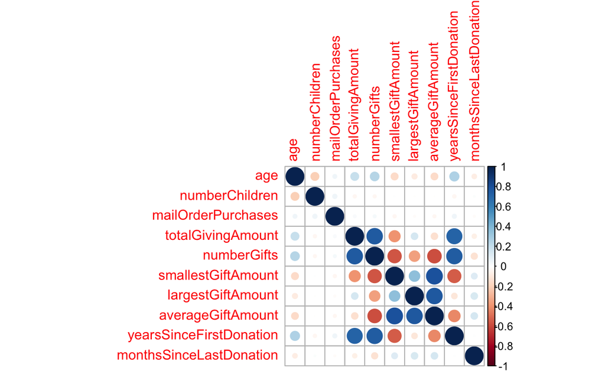

```r
donors %>%
  select(where(is.numeric)) %>%
  cor() %>%
  corrplot()
```

```r
vif(donorsModel)
```

```
                             GVIF Df GVIF^(1/(2*Df))
age                      1.189167  1        1.090489
numberChildren           1.068502  1        1.033684
incomeRating             2.361136  7        1.063289
wealthRating             2.606369 10        1.049064
mailOrderPurchases       1.411205  1        1.187941
totalGivingAmount        5.723039  1        2.392287
numberGifts              6.944928  1        2.635323
smallestGiftAmount       5.725547  1        2.392811
largestGiftAmount        4.665494  1        2.159975
averageGiftAmount       13.781345  1        3.712323
yearsSinceFirstDonation  2.967782  1        1.722725
monthsSinceLastDonation  1.144066  1        1.069610
inHouseDonor             1.071465  1        1.035116
plannedGivingDonor       1.019820  1        1.009862
sweepstakesDonor         1.059851  1        1.029490
P3Donor                  1.035682  1        1.017684
state                    1.753419 48        1.005867
urbanicity               2.356586  5        1.089503
socioEconomicStatus      2.522799  3        1.166757
isHomeowner              1.446846  1        1.202849
gender                   1.104828  3        1.016754
```

As can be seen above, there are some correlated features in our corrplot, and our VIF helps us confirm by examining anything with a VIF greater than 5, which points at: totalGivingAmount, numberGifts, smallestGiftAmount, averageGiftAmount. What’s interesting is we can see that our initial suspicions based purely on the corrplot were reduced by confirmation from our vif. Namely, yearsSinceFirstDonation and largestGiftAmount are safe to use as they’re less than 5, even though they appear highly correlated in the corrplot.

Let’s rebuild our model, this time cherry picking the significant features from our first model, and removing any identified high correlations.

```r
donorsModel2 <- glm(data = donorsTrain,
                    family = binomial,
                    formula = respondedMailing ~ numberChildren + incomeRating + wealthRating +
                      mailOrderPurchases + largestGiftAmount + yearsSinceFirstDonation +
                      monthsSinceLastDonation + inHouseDonor + plannedGivingDonor + sweepstakesDonor +
                      P3Donor + state + urbanicity + socioEconomicStatus + gender)

summary(donorsModel2)
```

```
Call:
glm(formula = respondedMailing ~ numberChildren + incomeRating +
    wealthRating + mailOrderPurchases + largestGiftAmount + yearsSinceFirstDonation +
    monthsSinceLastDonation + inHouseDonor + plannedGivingDonor +
    sweepstakesDonor + P3Donor + state + urbanicity + socioEconomicStatus +
    gender, family = binomial, data = donorsTrain)

Deviance Residuals:
    Min       1Q   Median       3Q      Max
-2.9756  -1.0217   0.0002   1.1181   2.4040

Coefficients:
                             Estimate Std. Error z value             Pr(>|z|)
(Intercept)                  0.977248   0.215218   4.541    0.000005605696842 ***
numberChildren              -0.145502   0.068837  -2.114             0.034540 *
incomeRating2                0.160471   0.092151   1.741             0.081616 .
incomeRating3                0.299478   0.100217   2.988             0.002805 **
incomeRating4                0.283272   0.095330   2.972             0.002963 **
incomeRating5                0.304110   0.093141   3.265             0.001094 **
incomeRating6                0.262592   0.107603   2.440             0.014672 *
incomeRating7                0.314306   0.111438   2.820             0.004795 **
incomeRatingUNK              0.313695   0.089706   3.497             0.000471 ***
wealthRating1                0.029367   0.171029   0.172             0.863666
wealthRating2               -0.183215   0.173715  -1.055             0.291568
wealthRating3               -0.014653   0.166436  -0.088             0.929847
wealthRating4               -0.161452   0.165382  -0.976             0.328947
wealthRating5               -0.143944   0.163458  -0.881             0.378524
wealthRating6               -0.311737   0.160884  -1.938             0.052667 .
wealthRating7               -0.094083   0.160261  -0.587             0.557161
wealthRating8               -0.197593   0.160701  -1.230             0.218859
wealthRating9               -0.066293   0.161867  -0.410             0.682135
wealthRatingUNK             -0.445614   0.140097  -3.181             0.001469 **
mailOrderPurchases          -0.050040   0.014839  -3.372             0.000746 ***
largestGiftAmount           -0.047138   0.003981 -11.842 < 0.0000000000000002 ***
yearsSinceFirstDonation      0.024207   0.006579   3.679             0.000234 ***
monthsSinceLastDonation     -0.043753   0.005962  -7.339    0.000000000000216 ***
inHouseDonorTRUE             1.273393   0.075544  16.856 < 0.0000000000000002 ***
plannedGivingDonorTRUE       3.015316   1.040676   2.897             0.003762 **
sweepstakesDonorTRUE         1.098604   0.131621   8.347 < 0.0000000000000002 ***
P3DonorTRUE                  1.690195   0.132084  12.796 < 0.0000000000000002 ***
```

[output cut: 54 more lines]

```
socioEconomicStatuslowest   -0.064564   0.063505  -1.017             0.309307
socioEconomicStatusUNK       0.551780   0.147519   3.740             0.000184 ***
genderjoint                  0.901358   0.338299   2.664             0.007713 **
gendermale                   0.063502   0.043865   1.448             0.147707
genderUNK                    0.255528   0.093257   2.740             0.006143 **
---
Signif. codes:  0 ‘***’ 0.001 ‘**’ 0.01 ‘*’ 0.05 ‘.’ 0.1 ‘ ’ 1

(Dispersion parameter for binomial family taken to be 1)

    Null deviance: 14817  on 10687  degrees of freedom
Residual deviance: 13102  on 10602  degrees of freedom
AIC: 13274

Number of Fisher Scoring iterations: 12
```

As can be seen above, our model now has all significant features, or in the case of dummy-coded factors, specific significant dummy codings.

```r
vif(donorsModel2)
```

```
                            GVIF Df GVIF^(1/(2*Df))
numberChildren          1.032769  1        1.016253
incomeRating            1.815026  7        1.043498
wealthRating            2.584293 10        1.048617
mailOrderPurchases      1.395433  1        1.181285
largestGiftAmount       1.079359  1        1.038922
yearsSinceFirstDonation 1.066334  1        1.032635
monthsSinceLastDonation 1.113252  1        1.055107
inHouseDonor            1.053670  1        1.026484
plannedGivingDonor      1.020095  1        1.009998
sweepstakesDonor        1.051679  1        1.025514
P3Donor                 1.033676  1        1.016698
state                   1.680505 48        1.005422
urbanicity              2.323396  5        1.087958
socioEconomicStatus     2.507927  3        1.165608
gender                  1.094630  3        1.015184
```

The vif confirms we no longer have multicollinearity issues since all values are below 5 now.

```r
donorsPred2 <- predict(donorsModel2, donorsTest, type = "response")
head(donorsPred2)
```

```
        1         2         3         4         5         6
0.4968009 0.3486484 0.3757952 0.2773850 0.2811726 0.5674296
```

Our predictions for the first 6 donors look a bit different than those made with our original model. Rather than generically deciding that the cutoff for 1 and 0 should be based on the 0.5 prediction value, let’s use a library that will determine the “ideal” cutoff.

```r
idealCutoff <- optimalCutoff(actuals = donorsTest$respondedMailing,
                             predictedScores = donorsPred2,
                             optimiseFor = "Both")
idealCutoff
```

```
[1] 0.389997
```

```r
donorsPred2 <- ifelse(donorsPred2 >= idealCutoff, 1, 0)
donorsPred2Table <- table(donorsTest$respondedMailing, donorsPred2)
donorsPred2Table
```

```
   donorsPred2
       0    1
  0 7422 9132
  1  287  602
```

```r
sum(diag(donorsPred2Table)) / nrow(donorsTest)
```

```
[1] 0.4600126
```